# Modeling Tree Diameter Growth

Author

Michael Betancourt

Published

January 2024

Because tree growth is sensitive to the surrounding environmental, in particular the ambient climate, continual measurements of tree growth are a powerful way to learn about the history of changes to that environment. In this exercise we’ll explore a Bayesian approach to modeling and drawing inferences from tree diameter data measurements, with a focus on capturing the underlying data generating process. At the end I’ll discuss how this exercise was integrated into a two-day interactive workshop.

# 1 Familiarizing Ourselves With The Data

Before building any models we need to understand is being modeled. In particular we need to develop our understanding of the data and its provenance.

## 1.1 Data Provenance

The data with which we’ll be working consists of **diameter at breast height**, or **DBH**, measurements. These measurements are made by wrapping a measuring tape around the trunk of a tree at a height of 1.37 meters, approximating the breast height of an average human (Figure 1). This height is high enough to avoid the tree roots and forest floor but low enough to be accessible to researchers making the measurements. Diameter observations are given by dividing the recorded circumference by $\pi$.

When the diameter of a tree is first measured it is marked with a tag to indicate the breast height used. All future diameter measurements are made at the tag height to ensure consistency across time.

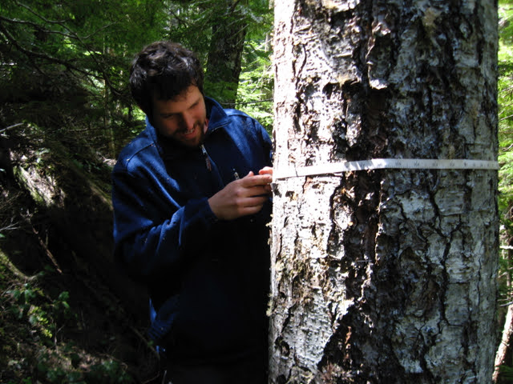

Figure 1: Tree diameters are measured by wrapping a measuring tape around the trunk of a tree 1.37 meters above the ground and then dividing the recorded circumference by $\pi$. Here Robert Ettinger is recording tree diameters in the Pacific Northwest. Photo :copyright: Ailene Ettinger, used with permission.

The H.J. Andrews Experimental Forest and Long Term Ecological Research Program has censused trees in forests across the Pacific Northwest every five or six years for decades. In addition to the tree diameter additional physiological attributes, such as tree vigor and the condition of the tree crown and stem are also recorded. If a tree is found to have died since it was last measured then a mortality assessment is also performed. For intimate detail on the measurement procedures and the structure of the resulting data see the [Pacific Northwest Permanent Sample Plot Program Protocol for Tree Measurements and Mortality Assessments](https://github.com/lizzieinvancouver/bayesian2024ubc/tree/main/data/treestands/metadata/PSP_tree_measurement_protocol_v2019.pdf).

In this exercise we will be focusing on data collected from forests around Mount Rainier (Figure 2). These forests cover a wide range of elevations and other environmental conditions which make them particularly well-suited for studying various aspects of an evolving climate. That said here we will consider only trees that are isolated to a single stand of forest.

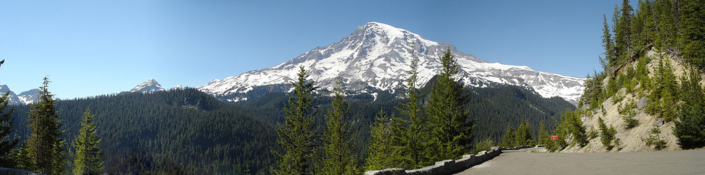

Figure 2: The forests around Mount Rainier span a diversity of environmental conditions. Photo courtesy of WikiMedia, https://commons.wikimedia.org/wiki/File:Mount_Rainier_panorama_2.jpg.

## 1.2 Code Environment Set Up

With the provenance established we’re ready to take our first peak at the data itself. We’ll start by configuring our local `R` environment for some reasonably aesthetic visualizations.

```r
par(family="sans", las=1, bty="l",
    cex.axis=1, cex.lab=1, cex.main=1,
    xaxs="i", yaxs="i", mar = c(5, 5, 3, 1))

c_light <- c("#DCBCBC")
c_light_highlight <- c("#C79999")
c_mid <- c("#B97C7C")
c_mid_highlight <- c("#A25050")
c_dark <- c("#8F2727")
c_dark_highlight <- c("#7C0000")

c_light_teal <- c("#6B8E8E")
c_mid_teal <- c("#487575")
c_dark_teal <- c("#1D4F4F")
```

## 1.3 Exploratory Data Analysis

We now read in our data for stand AV06. The columns and their possible values are carefully documented in [Pacific Northwest Permanent Sample Plot Program Protocol for Tree Measurements and Mortality Assessments](https://github.com/lizzieinvancouver/bayesian2024ubc/tree/main/data/treestands/metadata/PSP_tree_measurement_protocol_v2019.pdf).

```r
stand_tree_data <- read.csv('data/TV01002_v17_AV06.csv', skip=5)
```

To ensure that visualizations fit nicely into this document I’m going to restrict consideration to only the first 22 trees in the stand.

```r
tree_ids <-  unique(stand_tree_data$TREEID)

N_trees <- 22
tree_ids <- tree_ids[1:N_trees]
```

In this nominal format repeated measurements of a given tree are not necessarily organized next to each other. Because we are particularly interested in tree diameter growth it will be much more convenient to collect repeated measurements together and construct indices that allow us to readily isolate the data for a single tree.

Note how we’re using our understanding of the data generating process to motivate how we format and visualize the data. Exploratory data analysis is always done in the context of as assumed, if conceptual, data generating process!

```r
tree_N_obs <- c()
tree_start_idxs <- c()
tree_end_idxs <- c()
tree_years <- c()
tree_dbhs <- c()
tree_vigors <- c()
tree_species <- c()
tree_statuses <- c()
tree_notes <- c()

idx <- 1

for (id in tree_ids) {
  # Isolate observations for given tree
  tree_data <- stand_tree_data[stand_tree_data['TREEID'] == id,]

  years <- tree_data[,'YEAR']
  dbhs <- tree_data[,'DBH']
  vigors <- tree_data[,'TREE_VIGOR']
  species <- tree_data[,'SPECIES']
  statuses <- tree_data[,'TREE_STATUS']
  notes <- tree_data[,'CHECK_NOTES']

  # Append tree data
  N_obs <- length(years)
  tree_N_obs <- c(tree_N_obs, N_obs)

  start_idx <- idx
  end_idx <- idx + N_obs - 1
  idx <- idx + N_obs
  tree_start_idxs <- c(tree_start_idxs, start_idx)
  tree_end_idxs <- c(tree_end_idxs, end_idx)

  tree_years <- c(tree_years, years)
  tree_dbhs <- c(tree_dbhs, dbhs)
  tree_species <- c(tree_species, species)
  tree_vigors <- c(tree_vigors, vigors)
  tree_statuses <- c(tree_statuses, statuses)
  tree_notes <- c(tree_notes, notes)
}
```

Each tree diameter measurement is accompanied by many different assessments of the tree’s condition. For our initial investigation I take a look at **tree vigor** which is a general quantification of health. We can communicate tree vigor in our visualizations by coloring each observation according to the five possible statuses.

```r
vigor_cols <- list("1" = c_dark, "2" = c_mid, "3" = c_light,
                   "U" = c_mid_teal, "M" = "black")
```

```r
plot_tree_data <- function(t) {
  tree_idxs <- tree_start_idxs[t]:tree_end_idxs[t]

  years <- tree_years[tree_idxs]
  dbhs <- tree_dbhs[tree_idxs]
  vigors <- tree_vigors[tree_idxs]
  cols = sapply(vigors, function(v) vigor_cols[[v]])

  xlims <- range(years)
  delta <- xlims[2] - xlims[1]
  xlims[1] <- xlims[1] - 0.1 * delta
  xlims[2] <- xlims[2] + 0.1 * delta

  ylims <- range(dbhs, na.rm=TRUE)
  delta <- ylims[2] - ylims[1]
  ylims[1] <- ylims[1] - 0.1 * delta
  ylims[2] <- ylims[2] + 0.1 * delta

  plot(years, dbhs,
       main=paste0(tree_ids[t], "\nLocal Tree Index = ", t),
       pch=16, cex=0.8, col=cols,
       xlab="Year", xlim=xlims, ylab="DBH", ylim=ylims)

  na_idxs <- which(is.na(dbhs))
  for (na_idx in na_idxs) {
    abline(v=years[na_idx], col='#DDDDDD', lwd=3)
  }
}
```

So how does our data look?

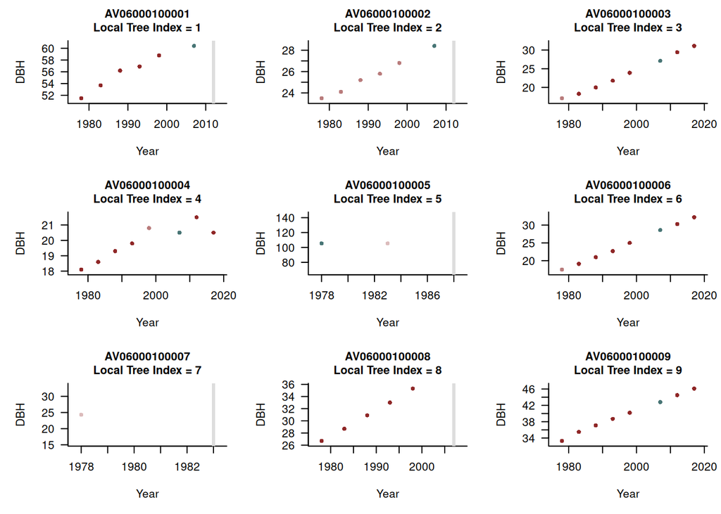

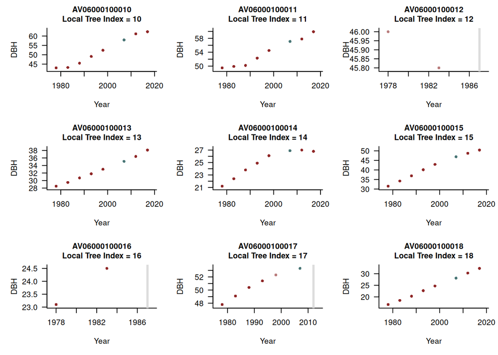

```r
par(mfrow=c(3, 3))
for (t in 1:18) {
  plot_tree_data(t)
}
```

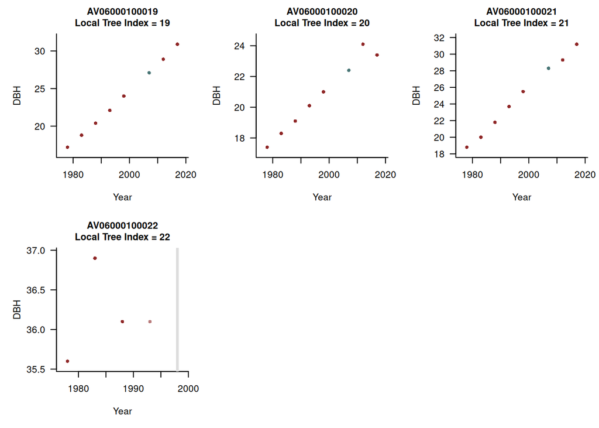

```r
par(mfrow=c(2, 3))
for (t in 19:N_trees) {
  plot_tree_data(t)
}
```

Most of the trees exhibit clean sequences of measurements that increase with time, consistent with persistent tree growth.

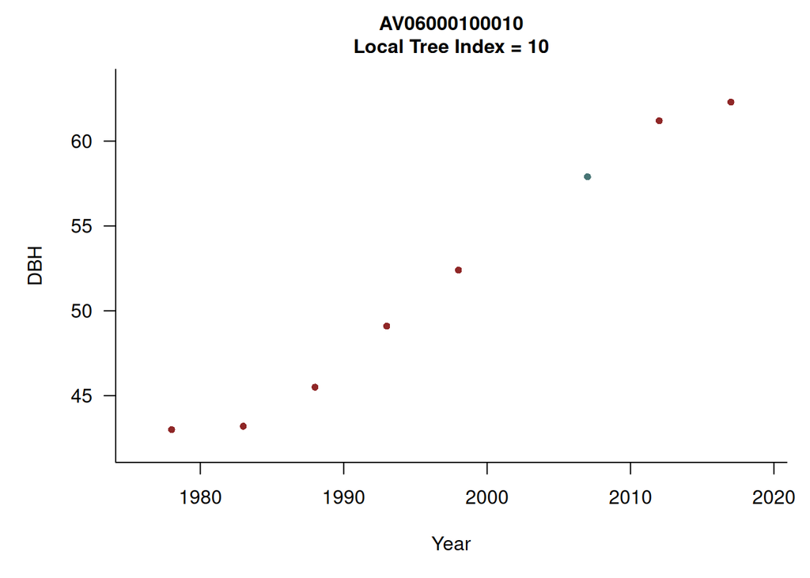

```r
par(mfrow=c(1, 1))

plot_tree_data(10)
```

Some trees, however, have perished resulting in `NA` diameter measurements.

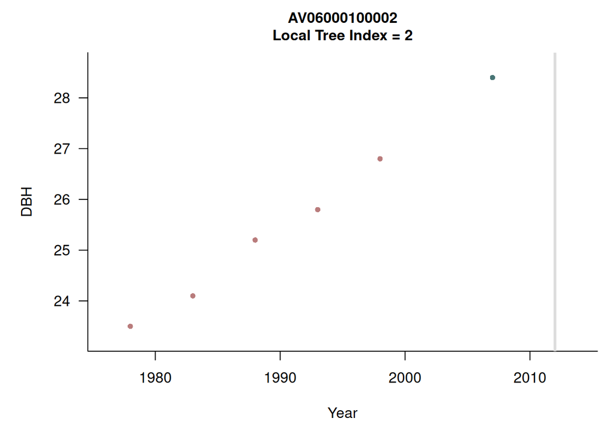

```r
plot_tree_data(2)
```

Still others contain only a few measurements which limits how well we can constrain potential growth models.

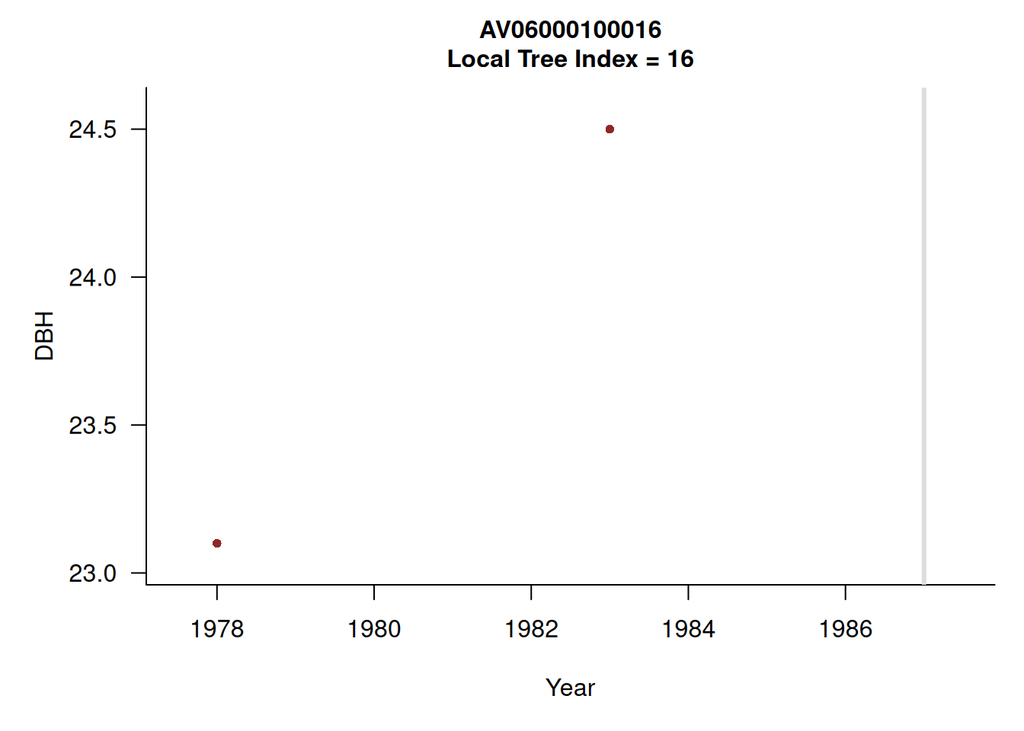

```r
plot_tree_data(16)
```

For our initial analysis let’s clean up the data by removing observations of dead trees, `DBH = NA` and `TREE_VIGOR = "M"`. Moreover let’s remove trees without at least four observations entirely. Why at least four observations? Eventually we will want to use four-parameter growth models that require at least four observations to be identified.

```r
good_tree_ids <- c()
tree_N_obs <- c()
tree_start_idxs <- c()
tree_end_idxs <- c()
tree_years <- c()
tree_dbhs <- c()
tree_vigors <- c()
tree_species <- c()
tree_statuses <- c()
tree_notes <- c()

idx <- 1

for (id in tree_ids) {
  # Isolate observations for given tree
  tree_data <- stand_tree_data[stand_tree_data['TREEID'] == id,]

  years <- tree_data[,'YEAR']
  dbhs <- tree_data[,'DBH']
  vigors <- tree_data[,'TREE_VIGOR']
  species <- tree_data[,'SPECIES']
  statuses <- tree_data[,'TREE_STATUS']
  notes <- tree_data[,'CHECK_NOTES']

  # Remove post-mortality observations
  good_obs <- which(vigors != "M")
  years <- years[good_obs]
  dbhs <- dbhs[good_obs]
  vigors <- vigors[good_obs]
  species <- species[good_obs]
  statuses <- statuses[good_obs]
  notes <- notes[good_obs]

  # Drop tree if there are not at least four observations
  N_obs <- length(years)
  if (N_obs < 4) next

  # Append tree data
  good_tree_ids <- c(good_tree_ids, id)
  tree_N_obs <- c(tree_N_obs, N_obs)

  start_idx <- idx
  end_idx <- idx + N_obs - 1
  idx <- idx + N_obs
  tree_start_idxs <- c(tree_start_idxs, start_idx)
  tree_end_idxs <- c(tree_end_idxs, end_idx)

  tree_years <- c(tree_years, years)
  tree_dbhs <- c(tree_dbhs, dbhs)
  tree_vigors <- c(tree_vigors, vigors)
  tree_species <- c(tree_species, species)
  tree_statuses <- c(tree_statuses, statuses)
  tree_notes <- c(tree_notes, notes)
}

N <- length(tree_years)
N_trees <- length(good_tree_ids)
```

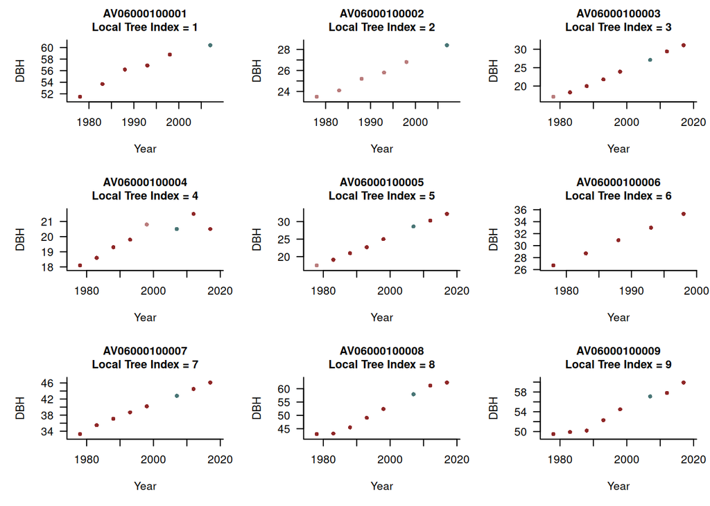

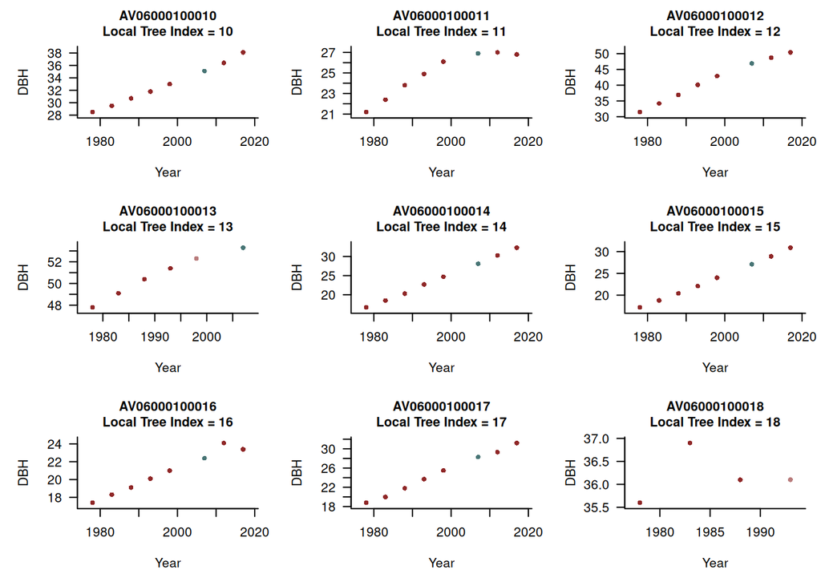

```r
par(mfrow=c(3, 3))

for (t in 1:N_trees) {
  plot_tree_data(t)
}
```

# 2 Modeling Tree Growth

Our exploratory data analysis didn’t reveal any behavior that we didn’t already expected from our understanding of the data generating process. We are now ready to model that data generating process, from the growth of an individual tree to the imperfect diameter measurements.

## 2.1 Tree Growth Models

Tree growth is a complicated process. In theory growth is moderated by the ambient environment which can change drastically across time. For example a tree with full exposure to sunlight should grow faster than a tree under the shadow of neighboring trees. Likewise limited access to water or other nutrients can inhibit growth. Moreover the physiological processes that drive growth might be complicated in of themselves, for example varying with the age of a tree.

In this section we will review some relatively simple growth models that might be useful for initial analyses. The construction of these models does require some nontrivial mathematics, and it is absolutely okay if those mathematics are inaccessible to some readers. Successful analyses often require collaboration between people who contribute scientific expertise and people who contribute mathematical expertise!

### 2.1.1 Linear Diameter Growth

A mathematically simple model for tree growth assumes that the diameter at breast height increases linearly with time (Figure 3)
$$d(t) = d_{0} + \beta \cdot (t - t_{0}).$$

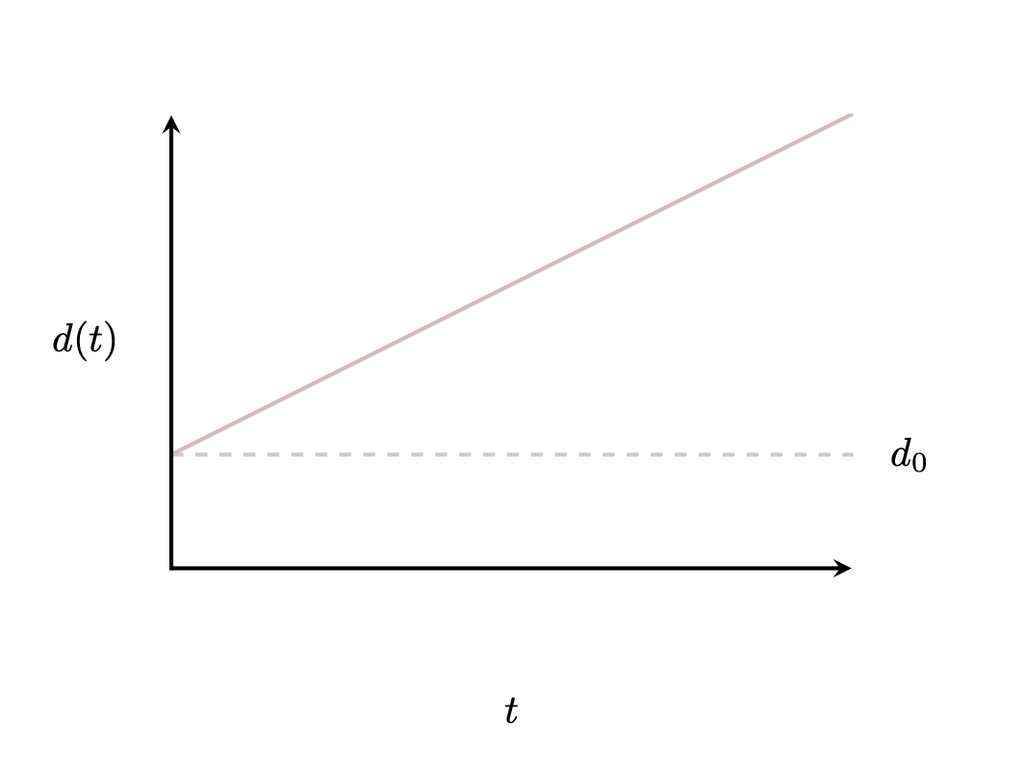

Figure 3: In a linear growth model a tree diameter grows linear with time.

Linear diameter growth over an extended time is often unrealistic, but it can be a reasonable approximation for more complicated growth dynamics over shorter intervals of time.

### 2.1.2 Linear Mass Growth

Linear diameter growth, however, also has awkward physiological consequences. As a tree grows a fixed increase in diameter requires larger and larger increases in overall mass.

If the energy inputs to a tree are fixed then an arguably more realistic model would assume that mass, and not diameter, increases linearly with time. To model this mathematically let’s assume that we can approximate trees as cylinders with constant density so that the total mass is related to the diameter by
$$\begin{align*}
m
&=
\text{density} \cdot \text{volume}
\\
&=
\rho \cdot \pi \, \left( \frac{d}{2} \right)^{2} \, h
\\
&=
\left( \frac{\pi}{4} \cdot \rho \cdot h \right) \, d^{2}
\\
&=
C \, d^{2}.
\end{align*}$$
For convenience I’ve absorbed everything but the diameter into a single constant in that last step.

If the tree mass grows linearly with time and the height remaining constant then
$$\begin{align*}
\delta m \cdot t
&=
m(t) - m_{0}
\\
&=
C \, d(t)^{2} - C \, d_{0}^{2},
\end{align*}$$
or upon solving for $d(t)$,
$$\begin{align*}
\delta m \cdot t
&=
C \, d(t)^{2} - C \, d_{0}^{2}
\\
\frac{\delta m}{C} \cdot t
&=
d(t)^{2} - d_{0}^{2}
\\
d(t)^{2}
&=
d_{0}^{2} + \frac{\delta m}{C} \cdot t
\\
d(t)
&=
\sqrt{ d_{0}^{2} + \frac{\delta m}{C} \cdot t }
\\
d(t)
&=
\sqrt{ d_{0}^{2} + \beta \cdot t }.
\end{align*}$$
Because of the square root function the diameter growth will decelerate as a tree ages, but never quite stop (Figure 4).

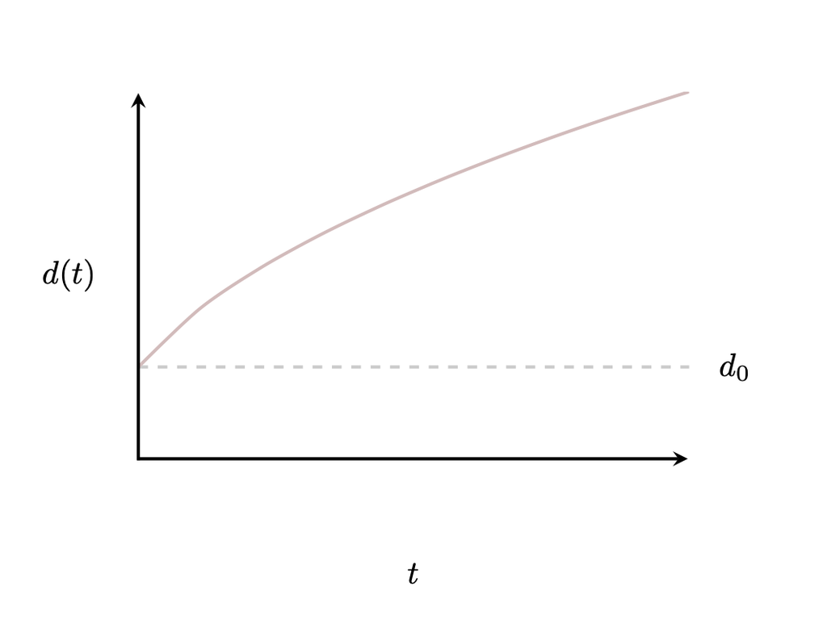

Figure 4: Under idealized assumptions a linear increase in the mass of a tree results in a square root increase in the diameter of the tree.

### 2.1.3 Gompertz Model

In practice both the linear and square root growth models will be too inflexible to adequately model tree diameter growth for the decades that our observations span. One particularly common class of models assume that the diameter growth follows a *sigmoidal curve*, allowing for accelerated growth at early ages, constant growth at intermediate ages, and decelerating growth at later ages. There are many mathematical curves that fit this qualitative shape, but a particularly common choice in many ecological applications is the **Gompertz** family of curves,
$$d(t) = d_{\max} \, \exp( -b \exp( -c \, t) ).$$
To ensure monotonically increasing growth all three parameters must be positive.

The interpretation of the parameter $d_{\max}$ is straightforward: it determines the asymptotic diameter that a tree will approach as it ages. On the other hand the interpretation of the other two parameters is less clear, which can frustrate a principled use of this model in a real analysis.

One way to make the Gompertz family of curves more interpretable is to find an alternative parameterization where each parameter directly corresponds to a meaningful behavior. For example we might parameterize the curves in terms of their linear behavior at intermediate times.

To that end let’s introduce the intermediate time $\tau$ where a given Gompertz curve reached half of its asymptotic diameter,
$$\frac{ d_{\max} }{ 2 }
= d(\tau)
= d_{\max} \exp( -b \exp( -c \, \tau) ),$$
or, solving for $\tau$,
$$\tau = \frac{ \log b - \log \log 2 }{ c }.$$
The rate of growth at $\tau$ is then given by
$$\beta
= \frac{ \mathrm{d} d }{ \mathrm{d} t }(\tau)
= \frac{ \log 2 }{ 2 } d_{\max} \, c.$$

Conveniently the tree values $d_{\max}$, $\tau$, and $\beta$ completely determine a Gompertz curve. In terms of these parameters the Gompertz family of curves becomes (Figure 5)
$$d(t) = d_{\max} \,
\exp \left( -\log 2 \cdot
\exp \left( -\frac{2}{\log 2} \, \frac{\beta}{d_{\max}} \,
\left( t - \tau \right) \right)
\right)$$
which is fortunately straightforward to implement in practice.

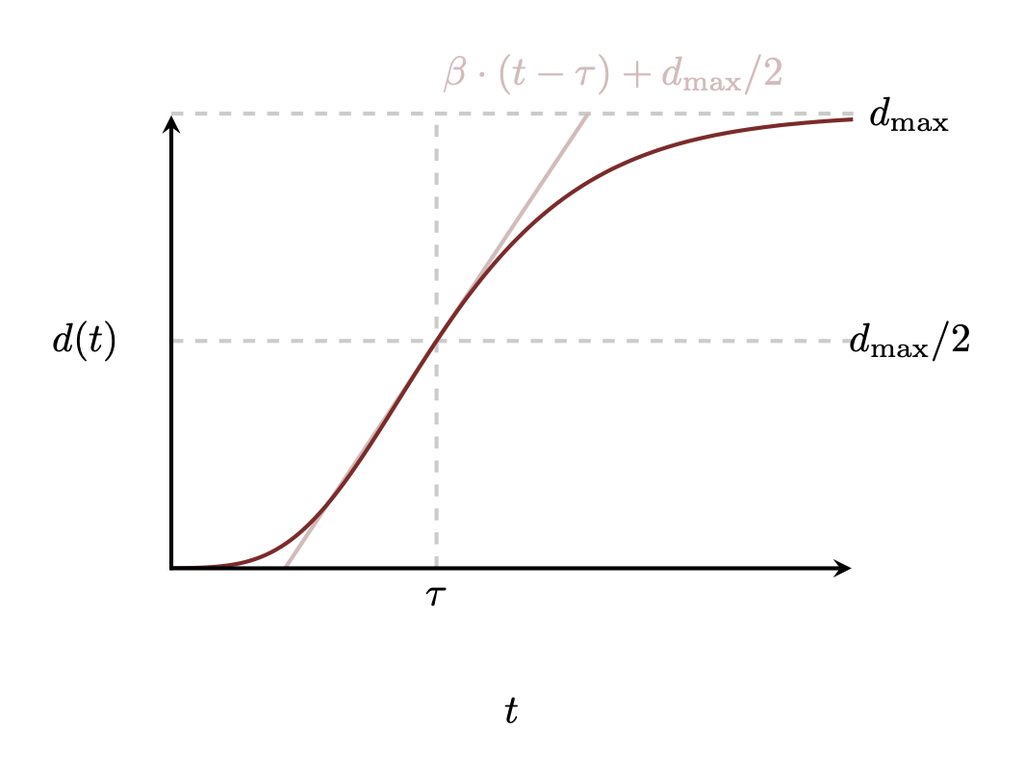

Figure 5: The Gompertz family of curves provides a sigmoidal model for tree diameter growth. Here we’ve parameterized each curve in terms of its asymptotic diameter, $d_{\max}$, the time at which curve reaches half of this value, $\tau$, and the derivative at $\tau$, $\beta$.

There are many ways of adding more flexible to the Gompertz model that could be useful when analyzing tree growth data. For example replacing $t - \tau$ with a polynomial would allow for more complicated, potentially even asymmetric, behavior at both young and old ages. Here we will consider a less sophisticated addition: a non-zero initial diameter,
$$d(t) = d_{0} + \delta d \,
\exp \left( -\log 2 \cdot
\exp \left( -\frac{2}{\log 2} \, \frac{\beta}{\delta d} \,
\left( t - \tau \right) \right).
\right)$$
This offset could, for instance, allow the model to accommodate different growth dynamics for very young trees before sigmoidal growth kicks in.

## 2.2 Measurement Model

Now that we have some candidate models for how tree diameter grows with time we need to consider how those diameters are actually measured.

The diameter at breast height measurement procedure is not infinitely precise. There can be errors in reading the measuring tape, misalignments of the measuring tape, non-uniforming in the diameter of the tree, inconsistencies from measurement to measurement, and more. A useful measurement model needs to account for not only how strongly these potential sources of variation can affect the diameter at breast height measurements but also what overall variation is consistent with our understanding of the procedure.

For example let’s consider how much misalignment of the measuring tape can affect diameter measurements. As we did in the linear mass growth model let’s assume that trees are well approximated by a cylinder of radius $r$, diameter $d = 2 \, r$, and height $h$, with all lengths in units of centimeters.

In a perfect diameter at breast height measurement the measuring tape will form a circle with the same circumference as the tree at the tag height. Consequently we can recover the diameter of the tree by dividing the measured length by $\pi$,
$$d = \frac{ C_{\mathrm{flat}} }{ \pi }.$$

When tape is tilted, however, it will form not a circle but rather an *ellipse*. If the maximum offset is given by $\delta$ then the shape of the ellipse will be determined by the semi-minor axis (Figure 6)
$$b = r = \frac{d}{2}$$
and the semi-major axis
$$a = \frac{1}{2} \sqrt{ d^{2} + \delta^{2} }.$$
As we would hope this reduces back to a circle with $a = b = r$ when $\delta \rightarrow 0$.

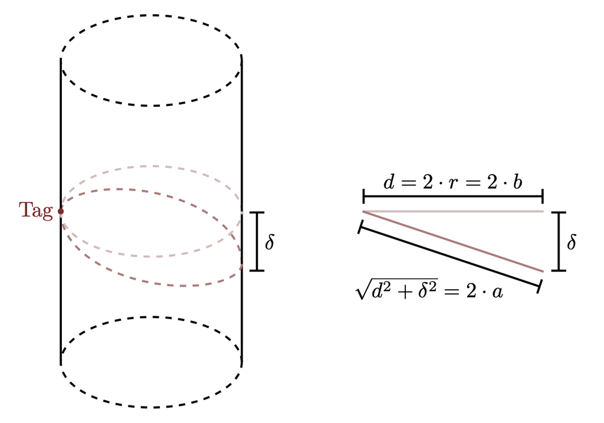

Figure 6: When misaligned a measuring tape wrapped around a cylindrical tree defines an ellipse. In this case dividing the measured length by $\pi$ does not give the tree diameter exactly.

Unfortunately the perimeter of an ellipse does not admit a simple mathematical form; instead it is given by a complicated function known as an **elliptic integral**. For those interested in learning more Wikipedia has a nice discussion at https://en.wikipedia.org/wiki/Ellipse#Circumference. We can, however, *approximate* the perimeter of an ellipse is a variety of different ways; again Wikipedia has a clear discussion, https://en.wikipedia.org/wiki/Ellipse#Arc_length.

For example the circumference of this tilted ellipse can be bounded above by
$$\begin{align*}
C_{\mathrm{tilt}}
&\le
\sqrt{2} \, \pi \, \sqrt{ b^{2} + a^{2} }
\\
&\le
\sqrt{2} \, \pi \,
\sqrt{ \left( \frac{d}{2} \right)^{2}
+ \left(\frac{1}{2}\right)^{2} \bigg( d^{2} + \delta^{2} \bigg)
}
\\
&\le
\sqrt{2} \, \pi \, \frac{1}{2} \sqrt{ d^{2} + d^{2} + \delta^{2} }
\\
&\le
\sqrt{2} \, \pi \, \frac{1}{2} \sqrt{ 2 d^{2} + \delta^{2} }
\\
&\le
\sqrt{2} \, \pi \, \frac{\sqrt{2} \, d}{2}
\sqrt{ 1 + \left( \frac{\delta}{2 \, d} \right)^{2} }
\\
&\le
\pi \, d \, \sqrt{ 1 + \left( \frac{\delta}{2 \, d} \right)^{2} }.
\end{align*}$$
If the offset $\delta$ is much smaller than the actual tree diameter $d$ then this upper bound will be a useful conservative approximation to the exact length of the tilted measuring tape,
$$C_{\mathrm{tilt}} \approx
\pi \, d \, \sqrt{ 1 + \left( \frac{\delta}{2 \, d} \right)^{2} }.$$

Using the perimeter of the tilted ellipse in place of the perimeter of a flat circle does not recover the diameter of the tree,
$$\frac{C_{\mathrm{tilt}}}{\pi}
=
d \, \sqrt{ 1 + \left( \frac{\delta}{2 \, d} \right)^{2} } \ge d.$$
The larger perimeter always biases the recovered diameter to larger values. When $\delta$ is unknown this bias manifests as an asymmetric variability in the measurements.

Note that this measurement variability is not additive but rather *multiplicative*. Indeed multiplicative measurement variability is common when working with measurements of positive quantities. One way to recover additive measurement variability is to work with log diameters,
$$\log \frac{C_{\mathrm{tilt}}}{\pi}
=
\log d
+ \frac{1}{2}
\log \left( 1 + \left( \frac{\delta}{2 \, d} \right)^{2} \right).$$

In practice we can sometimes approximate the multiplicative measurement variability with additive measurement variability,
$$\frac{C_{\mathrm{tilt}}}{\pi} \approx
d
+ d_{0}
\left( \sqrt{ 1 + \left( \frac{\delta}{2 \, d} \right)^{2} } - 1 \right),$$
where $d_{0}$ is the baseline diameter at which we want this approximation to be best. This approximation is decent if all of our measurements are limited to a narrow range of tree diameters, but if our data spans measurements of very small and very large trees then the approximation can break down at the extremes.

Assuming that an additive measurement model is a good enough approximation what do these variabilities look like in practice? If the offsets never exceed ten percent of the actual tree diameter, which allows for some pretty strong misalignments, then
$$\frac{ \delta }{ d } \approx 0.1,$$
$$\frac{ \delta }{ 2 \, d } \approx 0.05,$$
and
$$\sqrt{ 1 + \left( \frac{\delta}{2 \, d} \right)^{2} } \approx 1.001.$$
The deviation from the measured diameter to the true diameter is exceedingly small!

For example if $d_{0} = 50 \, \mathrm{cm}$ then the scale of the approximate additive measurement variability would be orders of magnitude smaller,
$$d_{0}
\left( \sqrt{ 1 + \left( \frac{\delta}{2 \, d} \right)^{2} } - 1 \right)
\approx 0.05 \, \mathrm{cm},$$
which we can round up to about a millimeter. This may appear surprisingly small but it’s all a consequence of the geometry: relatively large warpings of a circle don’t change the diameter as much as we might expect!

Analysis of the other potential sources of variation gives similar results: multiplicative variation is more realistic but additive variation can be a reasonable approximation, and the scale of the linear variation is unlikely to exceed a millimeter or so. For this exercise we’ll assume the simpler linear measurement model,
$$\hat{d}(t) \sim \text{normal}(d(t), \sigma),$$
with our domain expertise excluding values of $\sigma$ much larger than $0.1 \, \mathrm{cm}$. To be particularly conservative we will allow for measurement variabilities as large as $0.25 \, \mathrm{cm}$.

# 3 Demonstrative Analyses

Having brainstormed some possible models let’s try to incorporate them into a Bayesian analysis using the probabilistic programming tool `Stan`, in particular it’s `R` interface `RStan`.

## 3.1 Set Up

First and foremost we need to load the `rstan` package into our local `R` environment and configure it.

```r
library(rstan)
rstan_options(auto_write = TRUE)            # Cache compiled Stan programs
options(mc.cores = parallel::detectCores()) # Parallelize chains
parallel:::setDefaultClusterOptions(setup_strategy = "sequential")
```

Next we’ll load my recommended Markov chain Monte Carlo diagnostic and analysis code. The code itself as well as documentation can be found at https://github.com/betanalpha/mcmc_diagnostics.

```r
util <- new.env()
source('stan_utility_rstan.R', local=util)
```